# Graphics with ggplot2 (solution)

Science Data Lab & Center for Health Data Science

30 august, 2024

Loading the core tidyverse packages and the ‘readxl’ package for data import from .xlsx.

```r
library(tidyverse)
library(readxl)
```

Importing the climate data from **climate.xlsx**[^1].

Change the path to the Excel file below so that it matches the path to the file saved on your own computer, or use *Import Dataset* in RStudio to obtain the relevant code.

```r
#you may be able to just use read_excel("Data/climate.xlsx"), depending on your working directory.
climate <- read_excel("../2024_Sep/FromExceltoR/Data/climate.xlsx")
climate
```

```
## # A tibble: 60 × 7
##    station  year month    af  rain   sun device
##    <chr>   <dbl> <dbl> <dbl> <dbl> <dbl> <chr>
##  1 armagh   2016     1     5 132.   44.5 Campbell Stokes
##  2 armagh   2016     2    10  62.6  71.3 Campbell Stokes
##  3 armagh   2016     3     4  43.8 117.  Campbell Stokes
##  4 armagh   2016     4     5  54   140.  Campbell Stokes
##  5 armagh   2016     5     0  41.4 210.  Campbell Stokes
##  6 armagh   2016     6     0  75.1 114.  Campbell Stokes
##  7 armagh   2016     7     0  80.6 113.  Campbell Stokes
##  8 armagh   2016     8     0  52.5 135.  Campbell Stokes
##  9 armagh   2016     9     0  65.4  91.1 Campbell Stokes
## 10 armagh   2016    10     0  37.1  89.8 Campbell Stokes
## # ℹ 50 more rows
```

### Scatter plot I

**Solutions 1, 2, 3, 4**

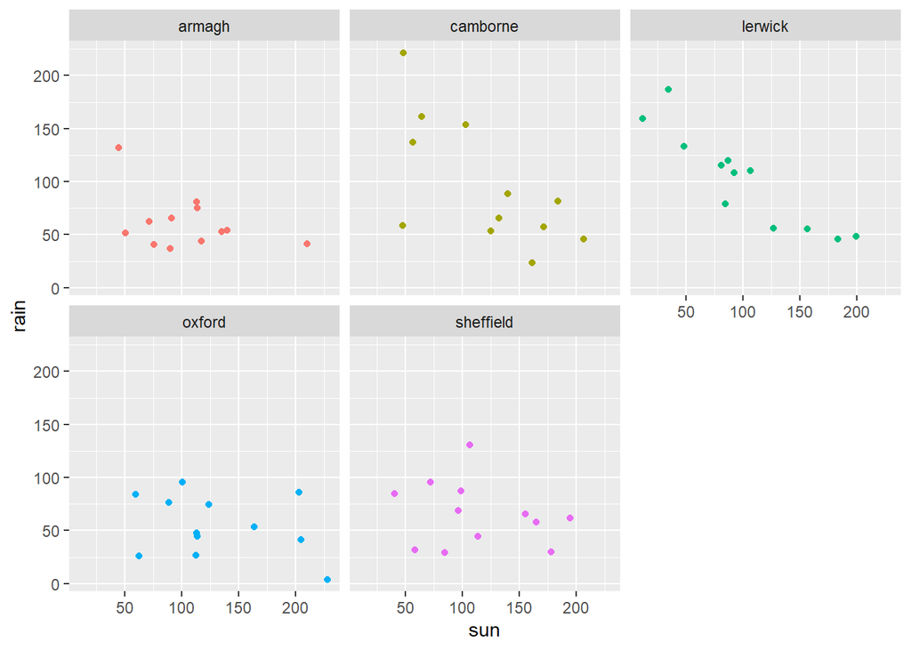

```r
p <- ggplot(climate, aes(x = sun, y = rain, colour = station)) +
  geom_point() +
  facet_wrap(~station) +
  theme(legend.position = "none")

p
```

### Graphic files

**5 check working directory**

```r
#getwd()
```

**6,7**

```r
ggsave(file="weather.jpeg")

ggsave(file="weather.png",width=10,height=8,units="cm")
```

### Scatter plot II: error bars

**8**

```r
summary_stats <- climate %>%
  group_by(month) %>%
  summarize(sun_avg = mean(sun), sun_sd = sd(sun))

summary_stats
```

```
## # A tibble: 12 × 3
##    month sun_avg sun_sd
##    <dbl>   <dbl>  <dbl>
##  1     1    45.3   9.19
##  2     2    86.2  19.5
##  3     3   113.   21.8
##  4     4   160.   16.0
##  5     5   193.   19.1
##  6     6   130.   40.3
##  7     7   152.   57.2
##  8     8   159.   46.2
##  9     9   105.    9.21
## 10    10   107.   19.7
## 11    11    68.0  15.9
## 12    12    45.9  20.1
```

**9**

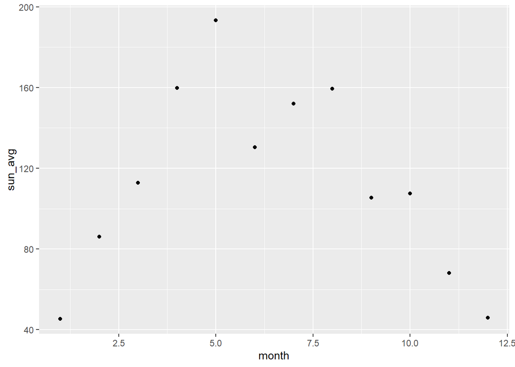

```r
p <- ggplot(summary_stats, aes(x = month, y = sun_avg)) +
  geom_point()

p
```

**10**

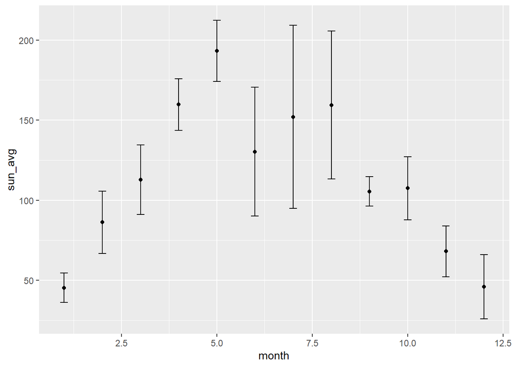

```r
p <- p + geom_errorbar(aes(ymin = sun_avg - sun_sd, ymax = sun_avg + sun_sd), width = 0.2)

p
```

**11**

Month cannot have an error since it’s categorical, so we need to flip the plot.

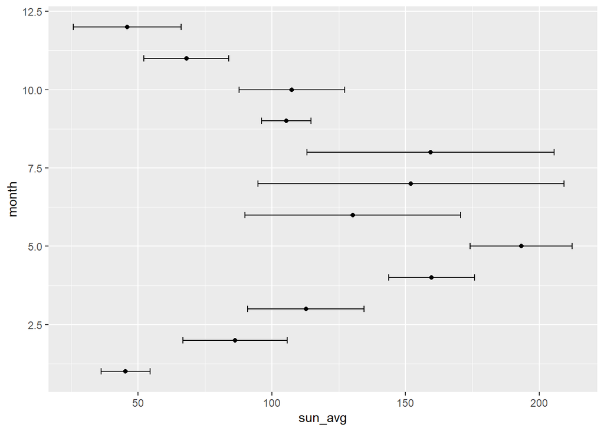

```r
p <- p + coord_flip()

p
```

### Line plot

**12**

You need the `group` aesthetic to group together the data points to be connected by lines.

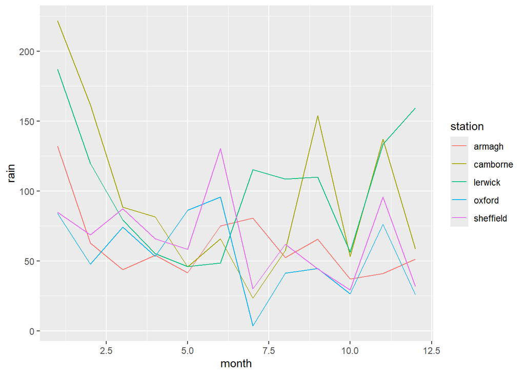

```r
ggplot(climate, aes(x = month, y = rain, group = station, colour = station)) +
  geom_line()
```

We get a continuous x axis.

**13**

But `month` should be categorical. We don’t have a data point for 7.5 months.

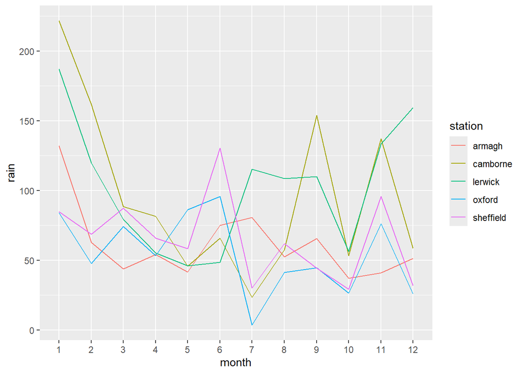

```r
climate <- climate %>%
  mutate(month = factor(month))

ggplot(climate, aes(x = month, y = rain, group = station, colour = station)) +
  geom_line()
```

Now the x-axis is discrete.

**14**

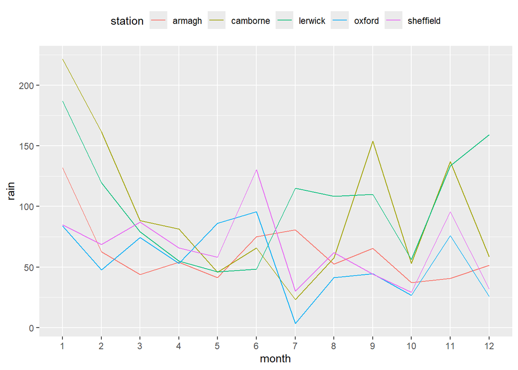

```r
ggplot(climate, aes(x = month, y = rain, group = station, colour = station)) +
  geom_line() +
  theme(legend.position = "top")
```

### Layering

**15**

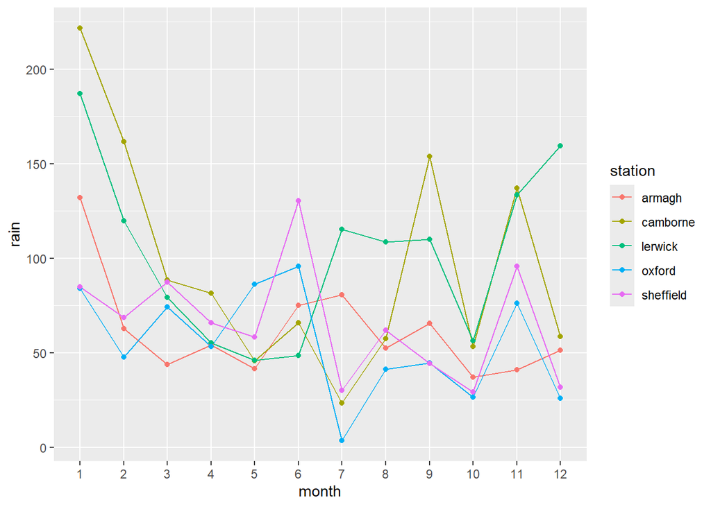

```r
ggplot(climate, aes(x = month, y = rain, group = station, colour = station)) +
  geom_line() +
  geom_point()
```

**16**

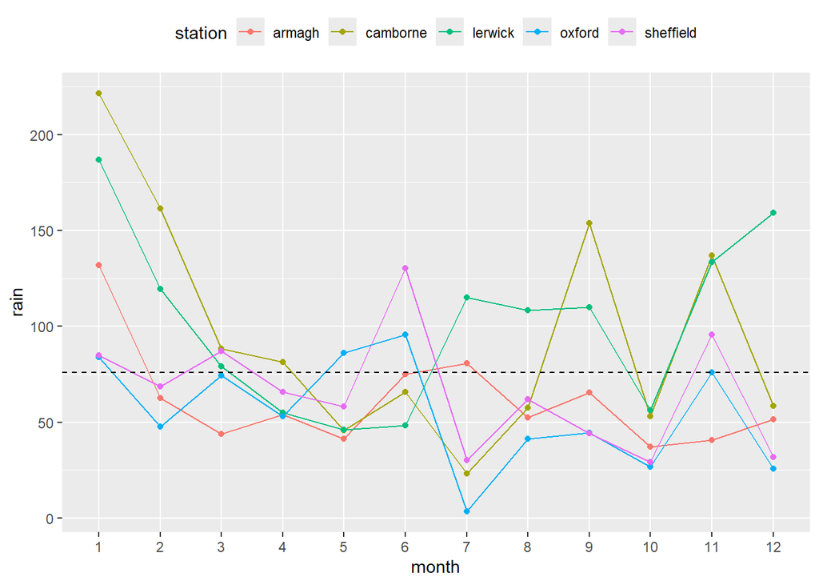

```r
ggplot(climate, aes(x = month, y = rain, group = station, colour = station)) +
  geom_line() +
  geom_point() +
  theme(legend.position = "top") +
  geom_hline(yintercept = mean(climate$rain), linetype = "dashed")
```

We have added a line that shows the average level of rainfall across all stations. Now we can see whenever stations are above or below the general average.

**17**

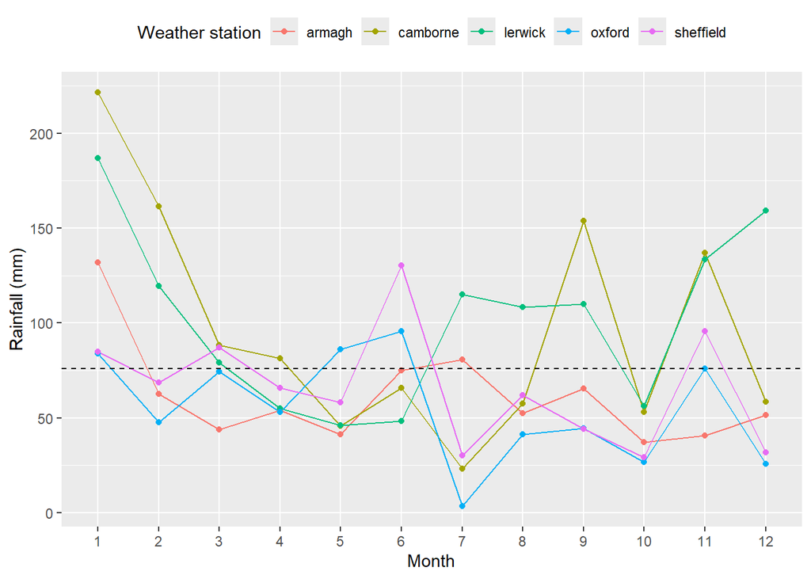

```r
climate <- mutate(climate, month = factor(month))

ggplot(climate, aes(x = month, y = rain, group = station, colour = station)) +
  geom_line() +
  geom_point() +
  theme(legend.position = "top") +
  geom_hline(yintercept = mean(climate$rain), linetype = "dashed") +
  labs(x = "Month", y = "Rainfall (mm)", colour = "Weather station")
```

### Box plot I

**Solutions 18,19**

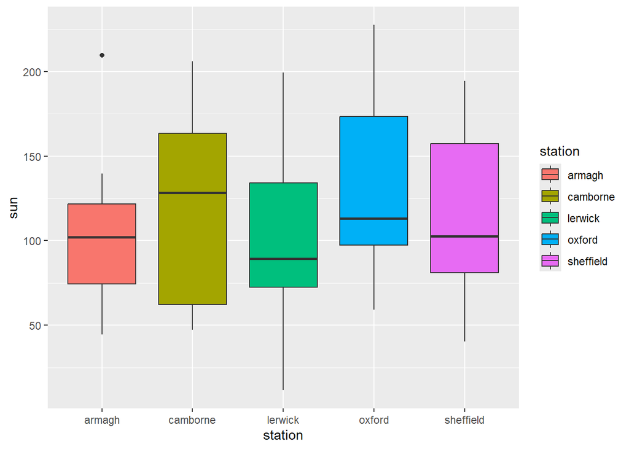

```r
ggplot(climate, aes(x = station, y = sun)) +
  geom_boxplot(aes(fill = station))
```

The `fill` aesthetic could also be inside the `ggplot` call.

### Box plot II - Aesthetics

**20**

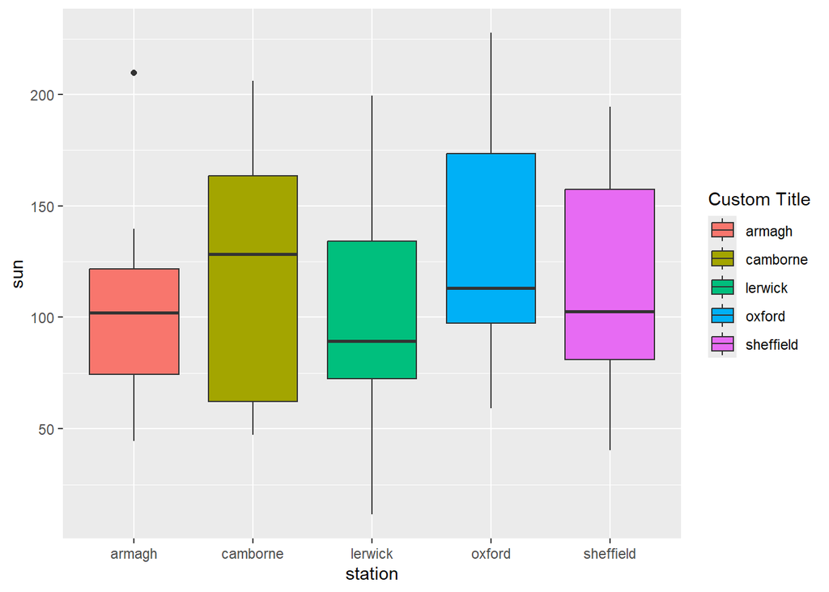

```r
ggplot(climate, aes(x=station, y=sun, fill=station)) +
  geom_boxplot() +
  labs(fill = "Custom Title")
```

**21**

Showing `theme_minimal()`:

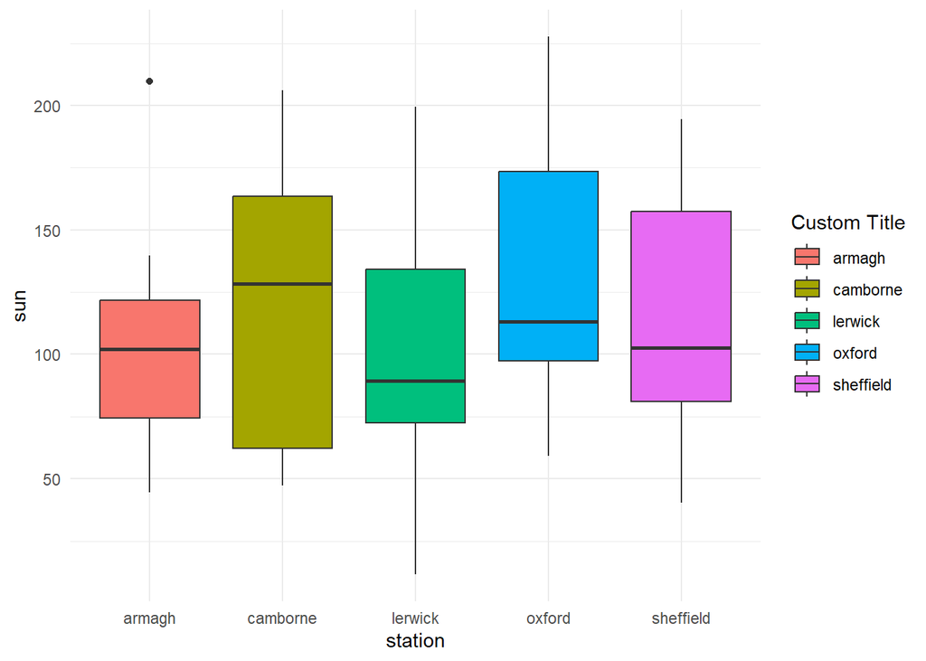

```r
#example
ggplot(climate, aes(x=station, y=sun, fill=station)) +
  geom_boxplot() +
  labs(fill = "Custom Title") +
  theme_minimal()
```

**22**

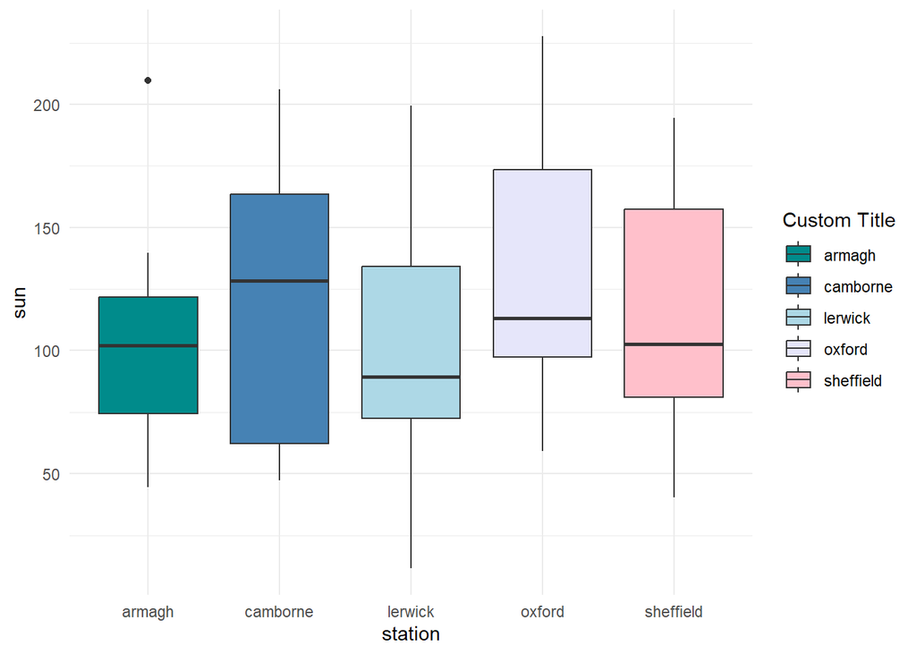

```r
ggplot(climate, aes(x=station, y=sun, fill=station)) +
  geom_boxplot() +
  labs(fill = "Custom Title") +
  theme_minimal() +
  scale_fill_manual(values = c("darkcyan","steelblue", "lightblue", "lavender", "pink"))
```

**23**

violin plot:

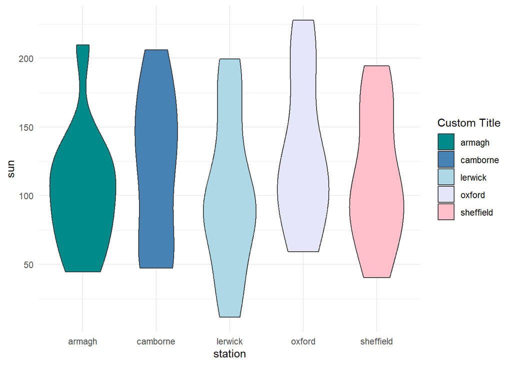

```r
ggplot(climate, aes(x=station, y=sun, fill=station)) +
  geom_violin() +
  labs(fill = "Custom Title") +
  theme_minimal() +
  scale_fill_manual(values = c("darkcyan","steelblue", "lightblue", "lavender", "pink"))
```

Plus scatter of the actual observations (`jitter`):

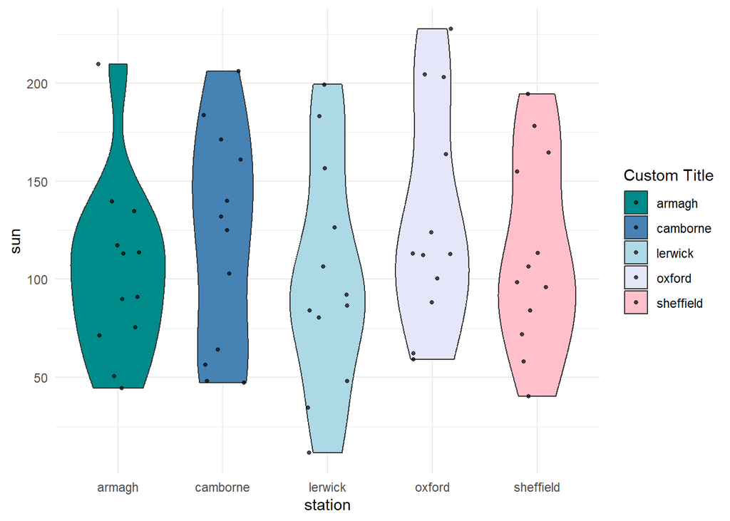

```r
ggplot(climate, aes(x=station, y=sun, fill=station)) +
  geom_violin() +
  geom_jitter(size = 1, alpha = 0.7, width = 0.2) +
  labs(fill = "Custom Title") +
  theme_minimal() +
  scale_fill_manual(values = c("darkcyan","steelblue", "lightblue", "lavender", "pink"))
```

Add small boxplots inside. So cute!

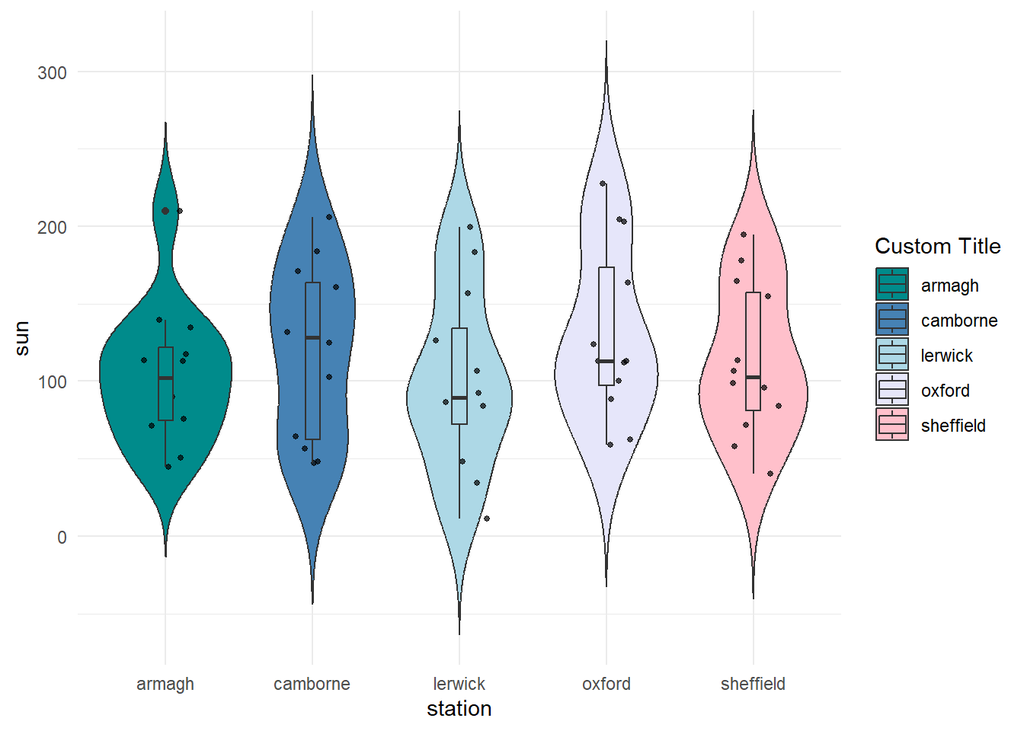

```r
ggplot(climate, aes(x=station, y=sun, fill=station)) +
  geom_violin(trim=FALSE) +
  geom_jitter(size = 1, alpha = 0.7, width = 0.2) +
  geom_boxplot(width=.1) +
  scale_fill_manual(values = c("darkcyan","steelblue", "lightblue", "lavender", "pink")) +
  labs(fill = "Custom Title") +
  theme(legend.position="top") +
  theme_minimal()
```

### Histogram

**24**

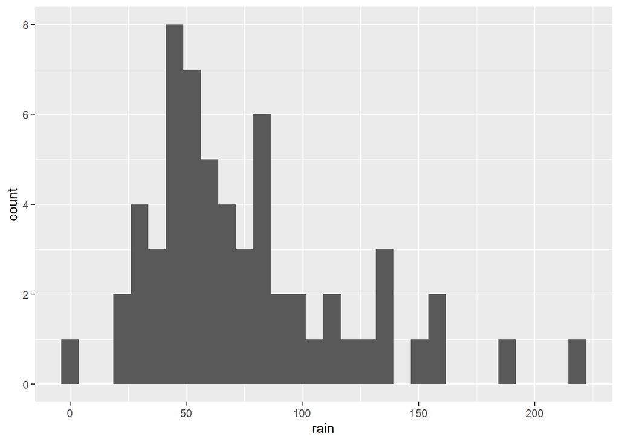

```r
ggplot(climate, aes(x = rain)) +
  geom_histogram()
```

**25**

Change width of histogram bins:

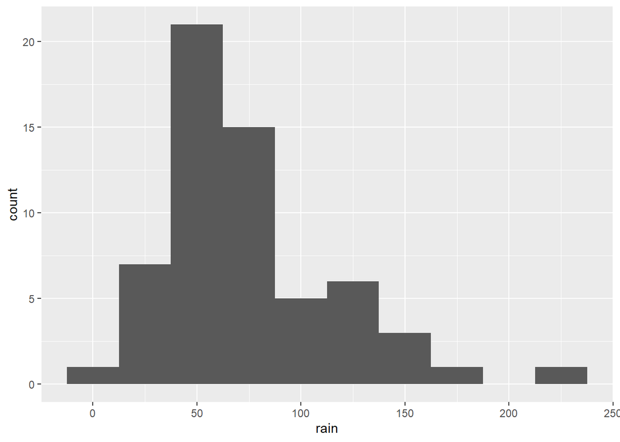

```r
ggplot(climate, aes(x = rain)) +
  geom_histogram(binwidth = 25)
```

**26**

Add colors. These arguments are outside the `aes` so they affect the entire plot!

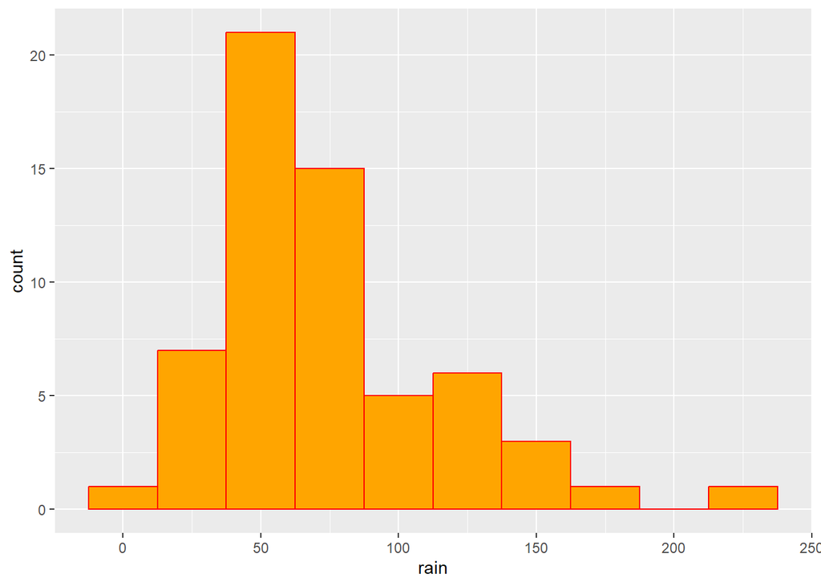

```r
ggplot(climate, aes(x = rain)) +
  geom_histogram(binwidth = 25, colour = "red", fill = "orange")
```

### Bar chart I

**27**

If month is not already a factor, do it now:

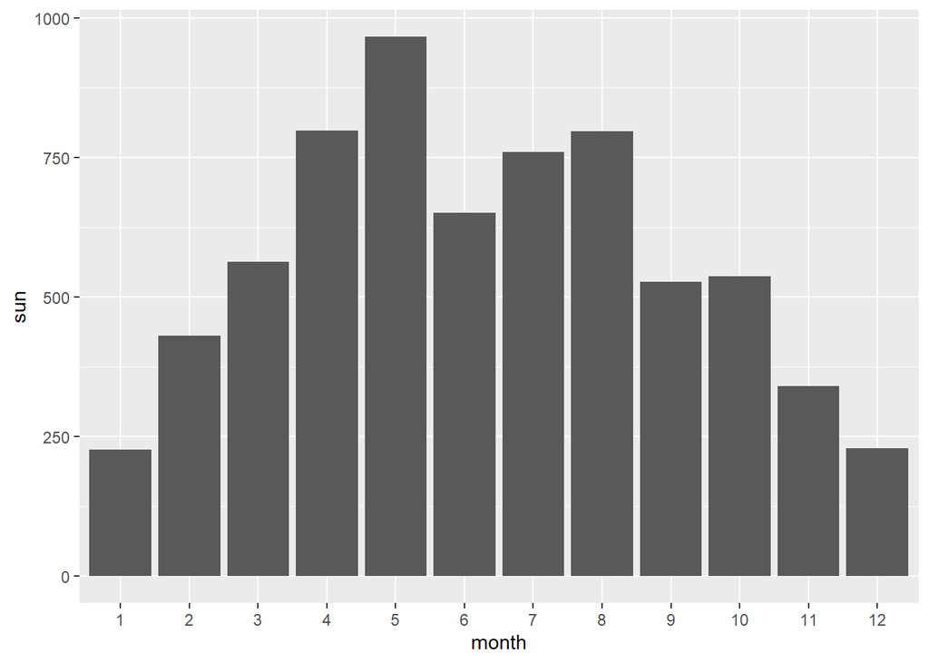

```r
climate <- climate %>%
  mutate(month = factor(month))

ggplot(climate, aes(x = month, y = sun)) +
  geom_col()
```

**28**

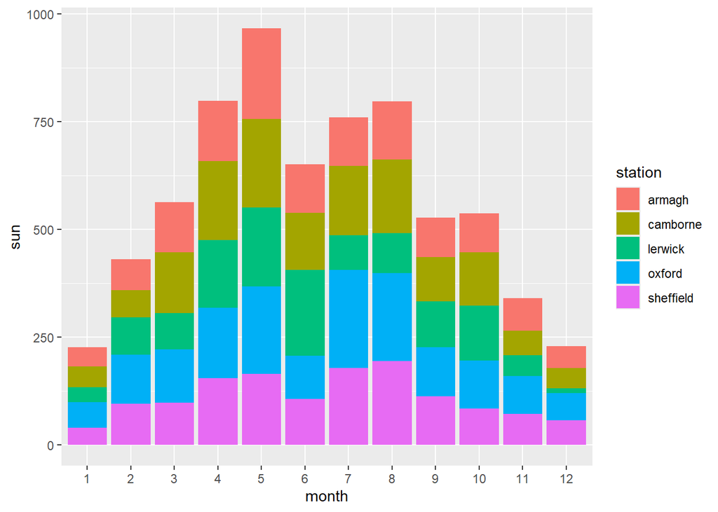

```r
ggplot(climate, aes(x = month, y = sun, fill = station)) +
  geom_col()
```

**29**

Side by side with `dodge`

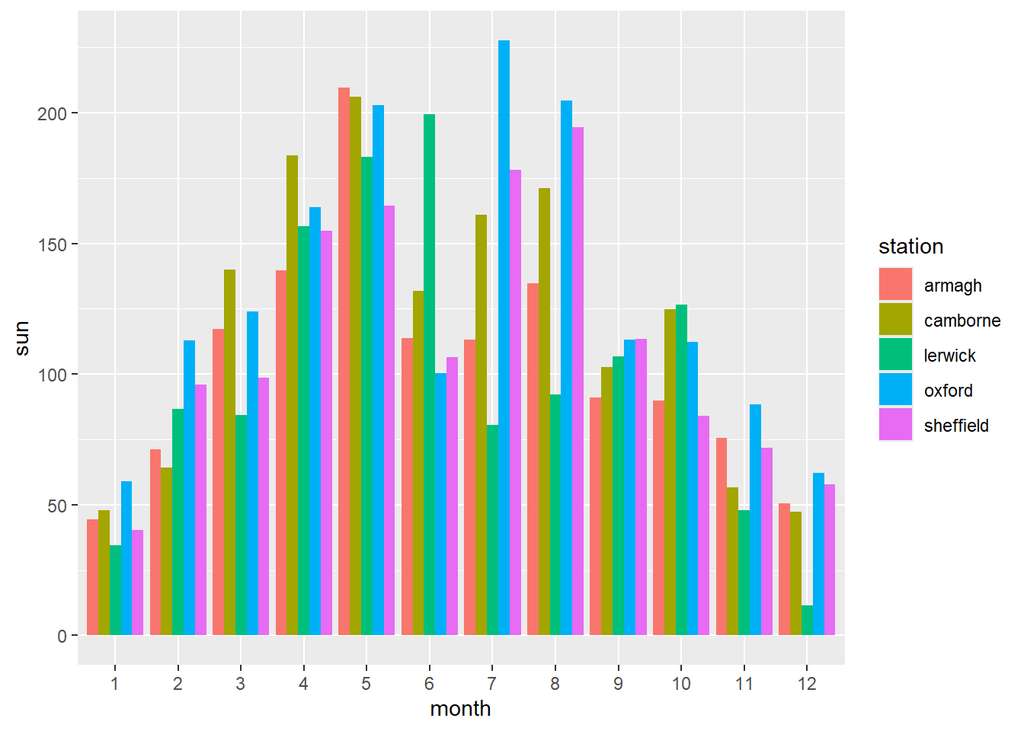

```r
ggplot(climate, aes(x = month, y = sun, fill = station)) +
  geom_col(position = 'dodge')
```

**30**

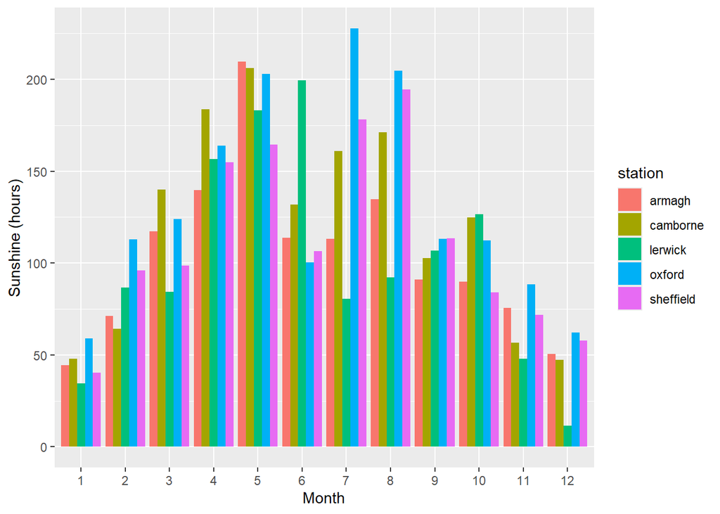

```r
ggplot(climate, aes(x = month, y = sun, fill = station)) +
  geom_col(position = 'dodge') +
  labs(x = "Month", y = "Sunshine (hours)", colour = "Weather station")
```

### Bar chart II

**31**

First, we need to calculate the annual rainfall. Annual means we sum the rainfall over the entire year, and we do this per station:

```r
annual_rain <-
  climate %>%
  group_by(station) %>%
  summarize(sum_rain = sum(rain))

annual_rain
```

```
## # A tibble: 5 × 2
##   station   sum_rain
##   <chr>        <dbl>
## 1 armagh        737.
## 2 camborne     1147.
## 3 lerwick      1218.
## 4 oxford        658.
## 5 sheffield     788.
```

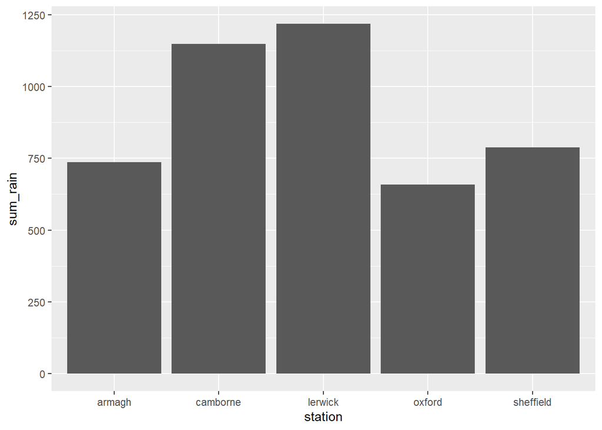

```r
ggplot(annual_rain, aes(x = station, y = sum_rain)) +
  geom_col()
```

**32**

Add sorting the factor levels of station after the sum of the rainfall so they will be ordered

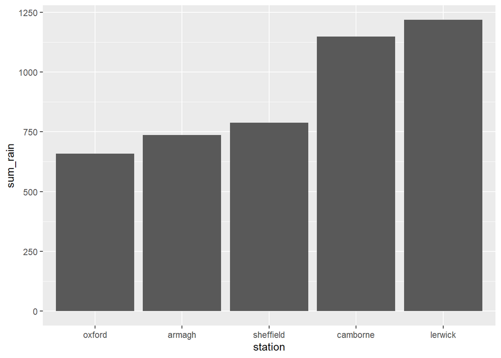

```r
#sort the df after the rainfall column
annual_rain <- annual_rain %>% arrange(sum_rain)

#add sorting the factor levels of station after the rainfall so they will be ordered
annual_rain <- annual_rain %>%
  mutate(station = factor(station, levels = annual_rain$station))

#remake the plot
ggplot(annual_rain, aes(x = station, y = sum_rain)) +
  geom_col()
```

**33**

Add labels that state the exact number in the bar.

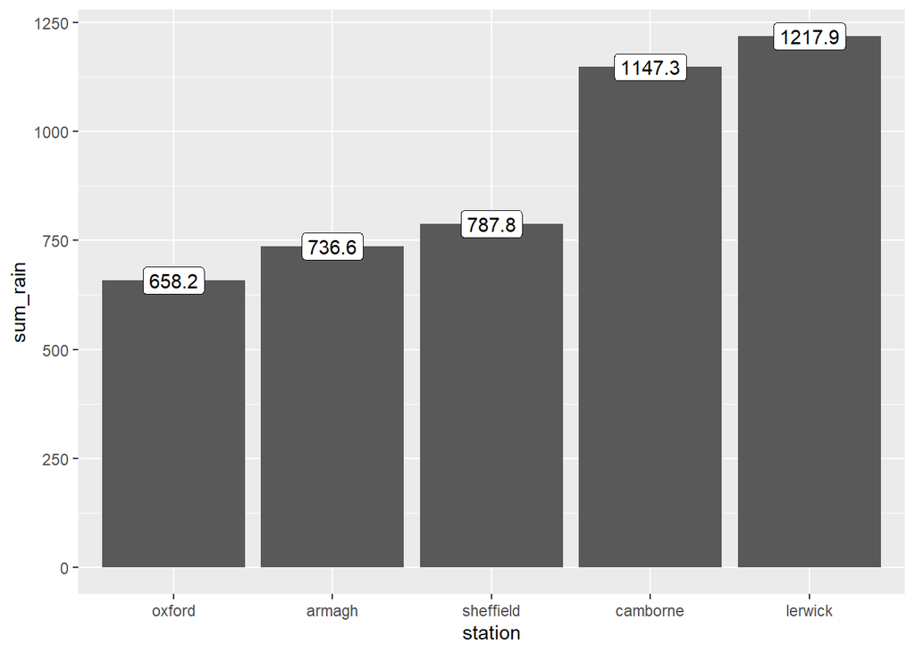

```r
ggplot(annual_rain, aes(x = station, y = sum_rain)) +
  geom_col() +
  geom_label(aes(label = sum_rain))
```

**34**

Adjust label position

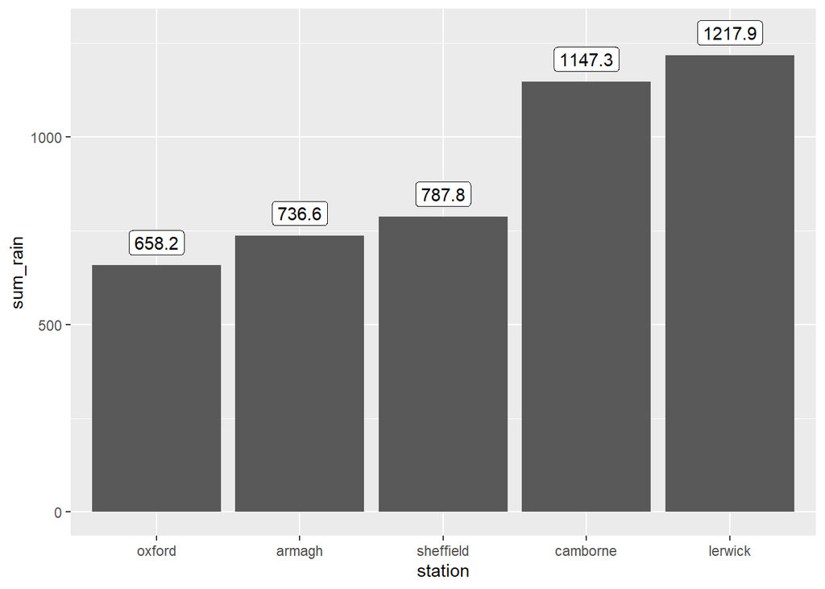

```r
ggplot(annual_rain, aes(x = station, y = sum_rain)) +
  geom_col() +
  geom_label(aes(label = sum_rain), nudge_y =  60)
```

[^1]: Contains public sector information licensed under the [Open Government Licence v3.0](http://www.nationalarchives.gov.uk/doc/open-government-licence/version/3/).